# Assignment 2

Kris Evers, i6202223

2019-10-13

## Introduction

In this assignment information about the boiling point of alkane molecules is requested by running a SPARQL query on the Wikidata database. Alkanes are molecules with only single bonds. It is too simple to assume a linear relationship between the number of carbon atoms of a molecule has and its boiling point. Different molecules with the same number of atoms have different structures. A branched alkane has a different boiling point than a unbranched alkane with the same number of carbon atoms. In this assignment multiple descriptors that describe some measure of the complexity of the structure are used to make a PLS model that is able to predict the boiling points of the alkanes. A list of alkanes, their boiling points and SMILES string is obtained with a query request to the Wikidata database.

### 1. Installing dependencies

In this project multiple R packages are required. The function ‘query_wikidata’ from the WikiQueryServiceR package [4] is used to parse a query that requests data from the WikiData database. rJava [5] is a dependency of the rcdk package [6] and thus needs to be installed here. The rcdk package (R chemical development kit) is used to parse the SMILES format and receive chemical descriptors which will be used in the PLS process as predictors for the boiling point. The ‘rmse’ function from the Metrics package [7] is used to calculate the error of the null model. The pls library [8] will be used to perform PLS process.

```r
  # install required packages
  install.packages(c("wikidataQueryServiceR", "rJava", "rcdk", "Metrics", "pls"))
```

### 2. Wikidata Query Service R

To fetch the boiling points and structural information of the molecules from the Wikidata database the function ‘query_wikidata’ from the WikidataQueryServiceR is used. This function parses a query in a format which is accepted by the WikiData Query Service. The alkane labels, boiling points, boiling point units and SMILES string are requested for all the distinct alkanes that are found in the database. SMILES strings are specifications of the chemical structure of a molecule in string format and will later be used to get chemical descriptors for the complexity of the chemical structure.

[134 alkanes are returned by the WikiData Query Service]

```r
  # load required package
  library(WikidataQueryServiceR) [4]
```

[output not shown]

```r
  # define and request query
  alkanes <- query_wikidata('SELECT DISTINCT ?ane ?aneLabel ?bp ?bpUnit ?bpUnitLabel ?SMILES
                      WHERE {   ?ane wdt:P31/wdt:P279* wd:Q41581 ;
                      wdt:P233 ?SMILES ;
                      p:P2102 [         ps:P2102 ?bp ;
                      psv:P2102/wikibase:quantityUnit  ?bpUnit         ] .
                      SERVICE wikibase:label { bd:serviceParam wikibase:language "[AUTO_LANGUAGE],en". } }
                      ')
```

```
134 rows were returned by WDQS
```

### 3.1. Boiling point conversion to kelvin

Because not all boiling points that are returned by the WikiData Query Service some of them need to be transformed so that all boiling points have the same unit and that they thus can be compared in analysis. Here is chosen to convert all boiling points in celcius and fahrenheit to kelvin, as kelvin is the most used unit in chemistry. There are R packages available which are able to perform this transformation, although here the choice is made to calculate the transformation by hand as it is a very straightforward calculation this gives more insight in the transformation.

```r
  # conversion of boiling point temperatures to degree kelvin
  alkanes$bp[alkanes$bpUnitLabel == "degree Celsius"]             <- alkanes$bp[alkanes$bpUnitLabel == "degree Celsius"] + 273.15
  alkanes$bpUnitLabel[alkanes$bpUnitLabel == "degree Celsius"]    <- "kelvin"
  alkanes$bp[alkanes$bpUnitLabel == "degree Fahrenheit"]          <- (alkanes$bp[alkanes$bpUnitLabel == "degree Fahrenheit"]-32)*5/9 + 273.15
  alkanes$bpUnitLabel[alkanes$bpUnitLabel == "degree Fahrenheit"] <- "kelvin"
```

### 3.2. Plot boiling point data

A plot of the boiling points of all the molecules is shown to indicated that there are no clear outliers in the obtained dataset.

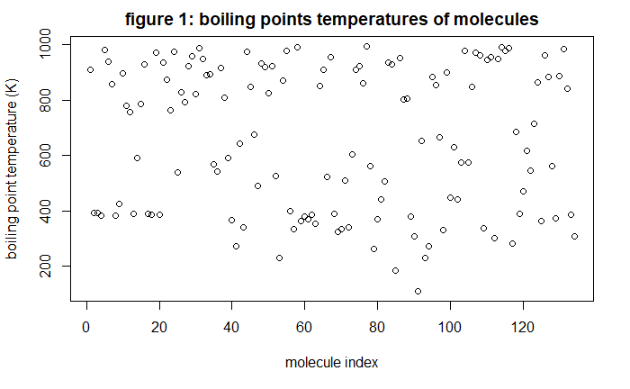

```r
  #plot the boiling point data
  plot(alkanes$bp, main = 'figure 1: boiling points temperatures of molecules',
                   xlab = 'molecule index',
                   ylab = 'boiling point temperature (K)')
```

### 4 Parse SMILES and get descriptor values

The R Chemical Development Kit has some useful functions for chemical calculations. It can parse SMILES strings and return an object called IAtomContainer. This object contains information about a molecule and can be used within the rcdk package to obtain other chemical information about the molecule like complexity, polarity, etc. This information is stored in descriptors of which its values are called using descriptor names and the function eval.desc. Here the Fragment Complexity Descriptor [1], the Wiener Number Descriptor [2] and the APol Descriptor [3] are used as they are measures of the complexity of a molecule and thus potentially good predictors of the boiling point of a molecule. The descriptors are briefly described here:

**FragmentComplexityDescriptor**: Returns the complexity of a system.

**WienerNumbersDescriptor**: This gives the Wiener numbers (see ref1). It returns the Wiener Path Number and the Wiener Polarity Number.

**APolDescriptor**: This describes the sum of the atomic polarizabilities.

[Java needs to be installed to run the next section (rJava is dependenct on Java). This code is built with java 1.8.0 installed]

```r
  # load required packages
  library(rJava)  # java required
  library(rcdk)   # rJava required

  # parsing the smiles column to a IAtomContainer
  parsed_smiles <- parse.smiles(alkanes$SMILES)

  # defining the molecular descriptors
  descNames <- c(
  'org.openscience.cdk.qsar.descriptors.molecular.FragmentComplexityDescriptor',
  'org.openscience.cdk.qsar.descriptors.molecular.WienerNumbersDescriptor',
  'org.openscience.cdk.qsar.descriptors.molecular.APolDescriptor'
  )
  # fetch the descriptors values per SMILES (i.e. molecule)
  descs <- eval.desc(parsed_smiles, descNames)

  # combine boiling point data and descriptors in one data frame
  bp_and_descs <- data.frame(alkanes$bp, descs)
```

### 5. Splitting data in training and test set

To build and test a PLS model of the data the data should be split in a training and a test set. The training set is by convention bigger than the test set. Here a random sample of 70% of the molecules will be stored in the training set. The rest of the data is put in the test set (30%).

[random sample seed = 5]

```r
  # set percentage of data that goes to the test set and the training set
  fraction_test <- floor(0.3 * nrow(bp_and_descs))
  # set a random seed for sampling (for reproducibility make sure the seed is set to 5 before running the sampling line)
  set.seed(5)

  # taking a random sample of of 30% of the data
  sample_test <- sample(seq_len(nrow(bp_and_descs)), size = fraction_test)
  # make a training set and a test set using the defined sample
  train <- bp_and_descs[-sample_test,]     # set the training set (70%)
  test  <- bp_and_descs[sample_test,]      # set the test set     (30%)
```

### 5. Null model

```r
  # load required package
  library(Metrics)

  # calculation of the null model
  null_model = mean(train$alkanes.bp)

  # error of the null model
  error_null_model <- rmse(test$alkanes.bp, null_model)
```

### 6. Partial least squares regression

PLS is a regression method related to principal component analysis although in PLS a linear regression model is projecting the observed and predicted variable in a new space so that the relationship between the variables can be captured in latent variables. The latent variables are linear combinations of the observed variables. The function ‘plsr’ from the pls package performs the PLS algorithm. It takes the dataframe containing the predicted (boiling point) and observable (descriptor values) variables. Cross validation is used as a validation method. Cross validation splits the specified data into a internal train and test set for multiple iterations and tests every model on its internal test set. This will improve the performance of the PLS method on prediction.

```r
  # load required package
  library(pls)

  # build the pls model using plsr function
  pls_model <- plsr(alkanes.bp ~ ., data = train, validation = "CV")

  # calculating the rms error on the test data for a different number of components
  error_pls_model <- RMSEP(pls_model, newdata = test)

  # predict the boiling point of the test set using the pls model
  predict_bp <- predict(pls_model, test)
```

### 7. Results

Here the results of the PLS regression are shown and conclusions are drawn from these results.

```r
  # plot the error to the number of components
  plot(error_pls_model, main = 'figure 2: error of the null model and the PLS model',
              xlab = '#components',
              ylab = 'RMSE (K)')
  abline(h=error_null_model, col="blue")
```

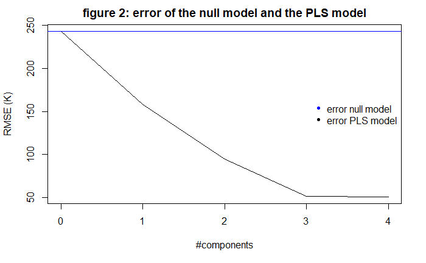

```r
  legend("right", c("error null model", "error PLS model"), col = c("blue", "black"), pch = c(20), bty = 'n')
```

#### Conclusion

```r
  # plot the prediction of the pls model on the test data, the ideal model and the null model
  plot(test$alkanes.bp, predict_bp[,,3], xlim=c(300,1000),
                                         ylim=c(300,1000),
                                         main = "figure 3: predicted vs measured boiling points",
                                         cex.main = 0.8,
                                         xlab = "measured boiling points (K)",
                                         ylab = "predicted boiling points (K)")
  lines(test$alkanes.bp, rep(null_model, length(test$alkanes.bp)), col = "blue")
```

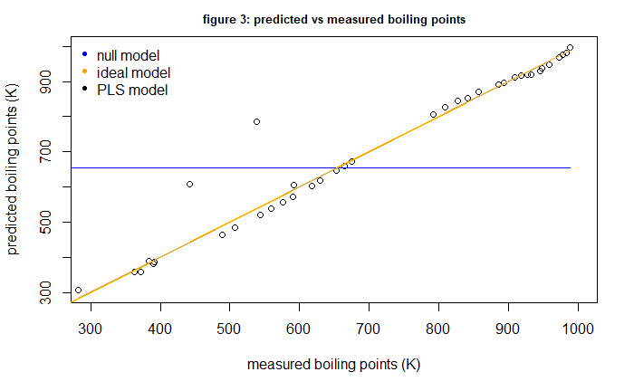

```r
  lines(test$alkanes.bp, test$alkanes.bp, col = "orange")
  legend("topleft", c("null model", "ideal model", "PLS model"), col = c("blue", "orange", "black"), pch = c(20), bty = 'n')
```

#### Conclusion

figure 3 shows that the PLS model has a generally linear shape and is closer to the ideal model than the null model. This means that the complexity descriptors that are used to predict the boiling point are able to predict the boiling point for most molecules with a root mean square error of 50 K.

### References

[1] Nilakantan, R. and Nunn, D.S. and Greenblatt, L. and Walker, G. and Haraki, K. and Mobilio, D., A family of ring system-based structural fragments for use in structure-activity studies: database mining and recursive partitioning., Journal of chemical information and modeling, 2006, 46:1069-1077

[2] Wiener, Harry, Structural Determination of Paraffin Boiling Points, Journal of the American Chemical Society, 1947

[3] https://cdk.github.io/cdk/1.5/docs/api/org/openscience/cdk/qsar/descriptors/molecular/APolDescriptor.html

[4] [WikidataQuerySerivceR](https://CRAN.R-project.org/package=WikidataQueryServiceR) Mikhail Popov (2017). WikidataQueryServiceR: API Client Library for ‘Wikidata Query Service’. R package version 0.1.1.

[5] rJava Simon Urbanek (2019). rJava: Low-Level R to Java Interface. R package version 0.9-11.

[6] [rcdk](https://cran.r-project.org/web/packages/rcdk/index.html) Guha, R. (2007). ‘Chemical Informatics Functionality in R’. Journal of Statistical Software 6(18)

[7] Metrics Ben Hamner and Michael Frasco (2018). Metrics: Evaluation Metrics for Machine Learning. R package version 0.1.4.

[8] pls Bjørn-Helge Mevik, Ron Wehrens and Kristian Hovde Liland (2019). pls: Partial Least Squares and Principal Component Regression. R package version 2.7-1.